# International News Analysis: Approaches Validation

Allan Sales

## Context

- International Media Bias
- Foreigner events are also important for our countries
- Media has great influence on people’s opinions
- Subjectivity rates might indicate whether media is biased or not

## Goal

- Measure news subjectivities

## Tools

- News from different publishers around the world
- Lexicons in portuguese

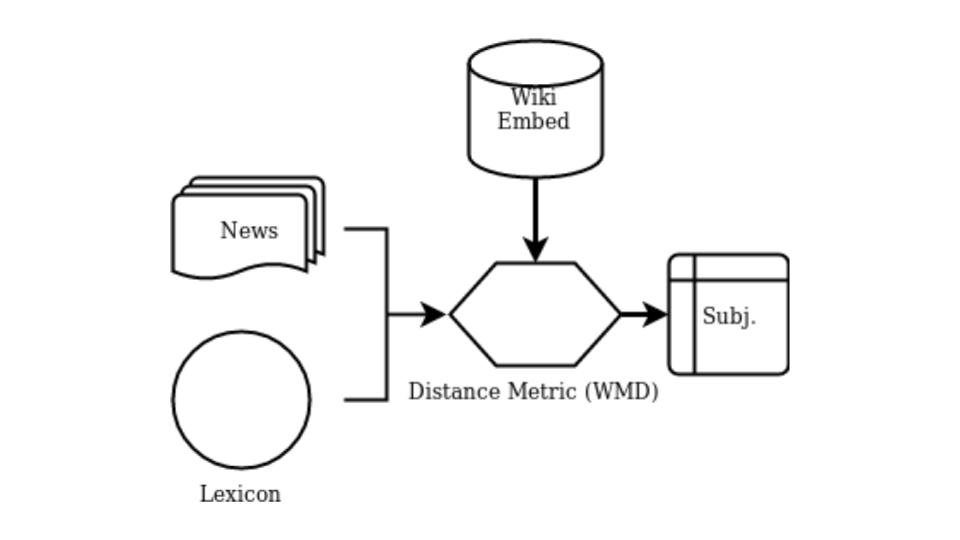

Subjectivity Rate Calculation Method

## Current Problem

- News are published in distinct languages
- Find a way to fairly analyze news subjectivities in distinct languages

## Approaches

- Translate Lexicons
- Translate News Articles

## First approach: Lexicons Translation

In this approach we translate the lexicons from portuguese to german/english and calculate the distance between articles and its correspondent lexicon. We use: deepL.com and https://en.pons.com/translate

### Dataset

```
## # A tibble: 6 x 3
## # Groups:   lang [3]
##   lang  opinative     n
##   <chr> <lgl>     <dbl>
## 1 deu   FALSE      2268
## 2 deu   TRUE         12
## 3 eng   FALSE     21570
## 4 eng   TRUE        287
## 5 por   FALSE      4139
## 6 por   TRUE         60
```

### Data distribuition

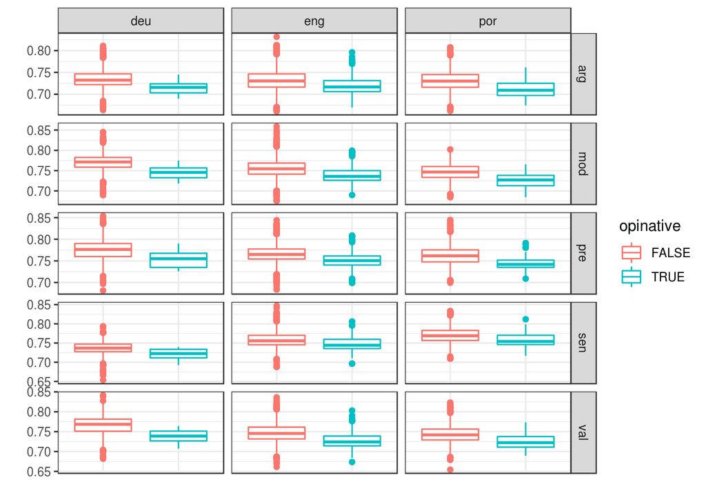

### Is the subjectivity of informative and opinative news significantly different?

Each confidence interval represents the difference between the subjectivity rates of opinative and informative news articles.

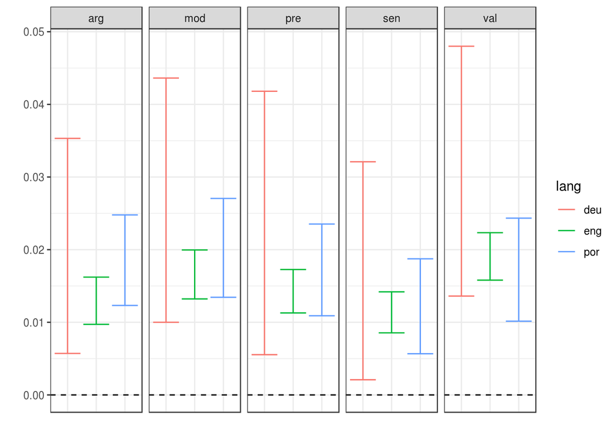

## Second Approach: News Translation

In this approach we translate the news from english/german to portuguese and calculate the distance between articles and portuguese lexicons. The news articles were manually translated using google.translate.

### Dataset

- 101 translated news articles

```
## # A tibble: 4 x 3
## # Groups:   lang [2]
##   lang  opinative     n
##   <chr> <lgl>     <dbl>
## 1 deu   FALSE        30
## 2 deu   TRUE         11
## 3 eng   FALSE        30
## 4 eng   TRUE         30
```

### Data distribution

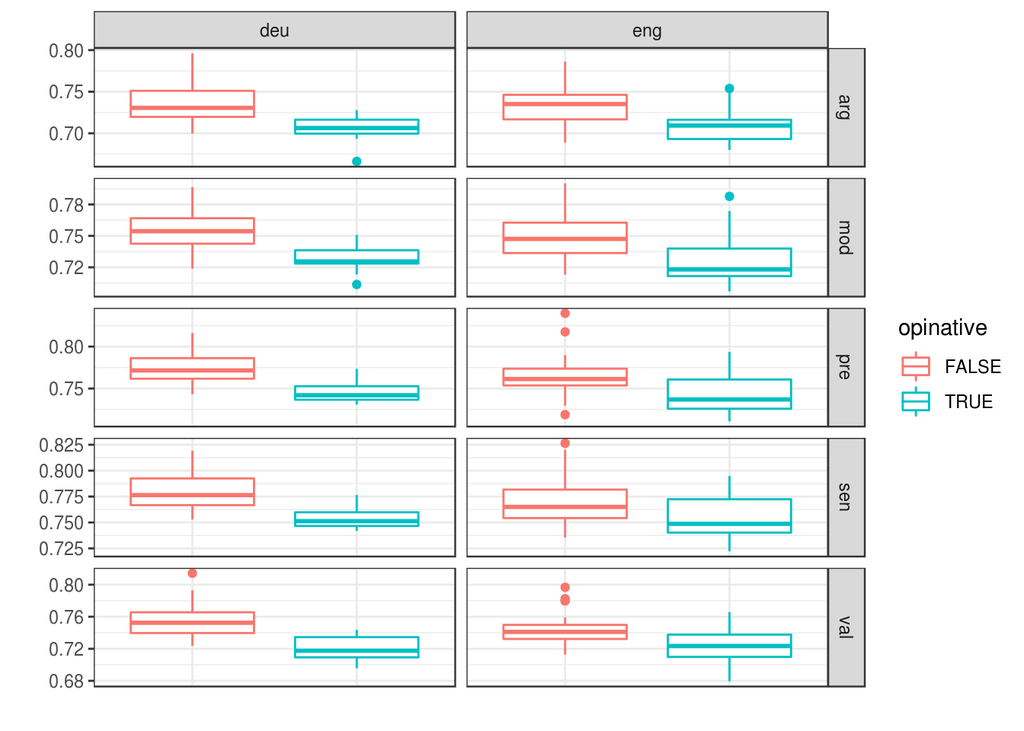

### Is the subjectivity of informative and opinative news significantly different?

Each confidence interval represents the difference between the subjectivity rates of opinative and informative news articles.

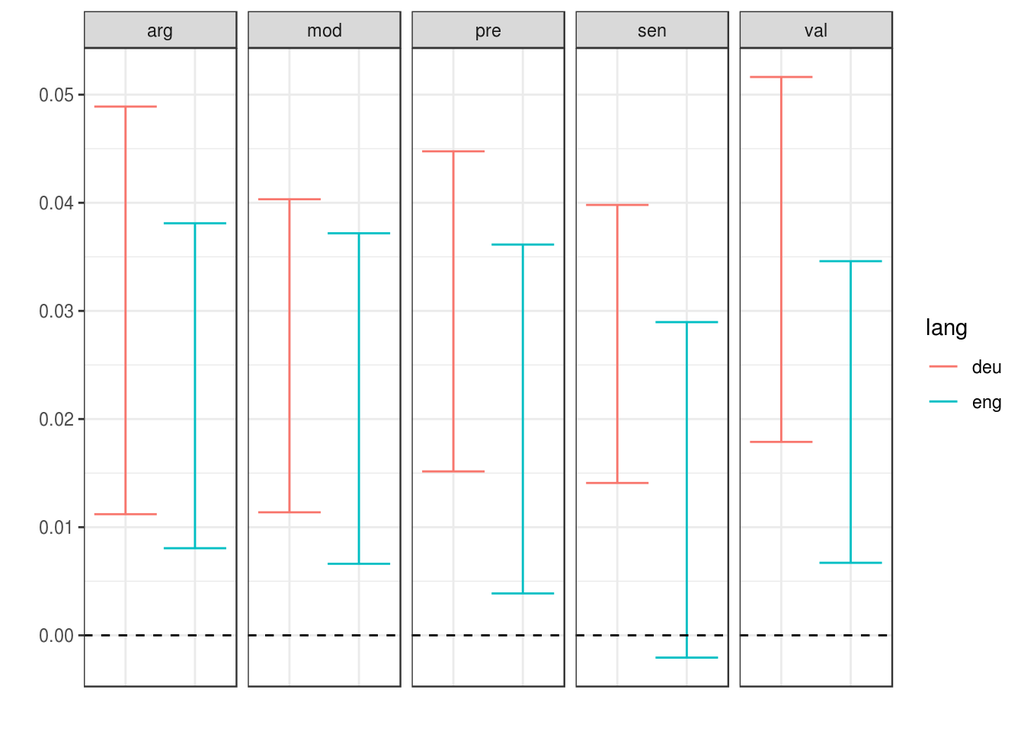

## News Translation x Lexicon Translation

Goal: Verifying whether the subjectivity levels are significantly different between the approaches

### Difference between the approaches subjectivities rates with 99% of confidence level

Each confidence interval represents the difference between the subjectivity rates of the two approaches

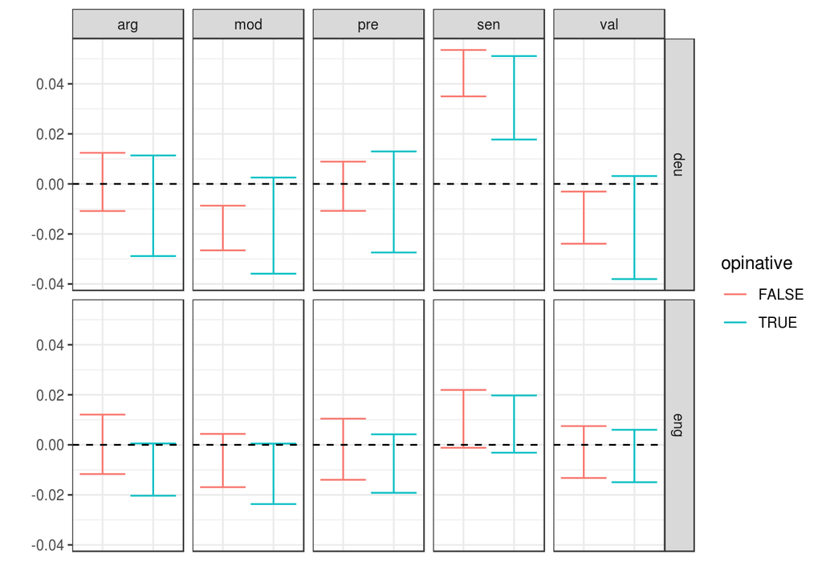

Significantly different with 99% of confidence level:

```
## # A tibble: 4 x 4
## # Groups:   lang, variable, opinative [4]
##   lang  variable opinative  p.value
##   <chr> <chr>    <lgl>        <dbl>
## 1 deu   mod      FALSE     7.06e- 6
## 2 deu   sen      FALSE     7.32e-14
## 3 deu   sen      TRUE      1.10e- 5
## 4 deu   val      FALSE     1.28e- 3
```